# XGBoost Classifier Tutorial 极致梯度提升分类模型教程

# Combo plots排版

Combo plots to published-ready figure

组合多个子图为发表格式

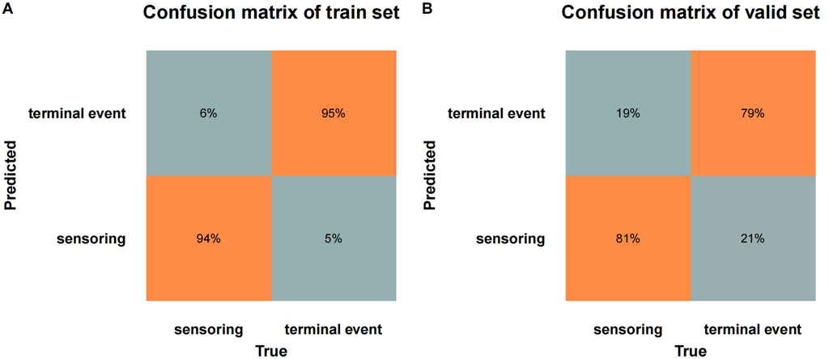

[figure not shown]

```r
library(cowplot)
width = 89
height = 59
p0 = plot_grid(p_confusion_train, p_confuction_val, labels = c("A", "B"), ncol = 2)
ggsave("results/XGBoost_model_results_combined.pdf", p0, width = width * 3, height = height * 2, units = "mm")
```

If used this script, please cited: 使用此脚本，请引用下文：

**Yong-Xin Liu**, Lei Chen, Tengfei Ma, Xiaofang Li, Maosheng Zheng, Xin Zhou, Liang Chen, Xubo Qian, Jiao Xi, Hongye Lu, Huiluo Cao, Xiaoya Ma, Bian Bian, Pengfan Zhang, Jiqiu Wu, Ren-You Gan, Baolei Jia, Linyang Sun, Zhicheng Ju, Yunyun Gao, **Tao Wen**, **Tong Chen**. 2023. EasyAmplicon: An easy-to-use, open-source, reproducible, and community-based pipeline for amplicon data analysis in microbiome research. **iMeta** 2: e83. https://doi.org/10.1002/imt2.83

Copyright 2016-2024 Defeng Bai baidefeng@caas.cn, Chuang Ma 22720765@stu.ahau.edu.cn, Jiani Xun 15231572937@163.com, Yong-Xin Liu liuyongxin@caas.cn